# Repeated measures volume

# Single-set vs multiple-set training for strength development

## Introduction

What is the recommended volume for strength development, single- or multiple-set training? Schlumberger et al. (2001) have previously conducted a 6 weeks training intervention on women, where the participants performed either one-set or multiple-set training. They found significant strength improvements in both groups (6 % and 15 %, respectively), but calculation of effect sizes and percentage gains revealed higher strength gains in the multiple-set group compared to the single-set group. These findings is supported by a meta analysis conducted by Galvão et al. (2004), who states that studies prior to 1998 demonstrated inconsistent findings between single-set and multiple-set programs, but that recent evidence suggests that multiple-set programs promote additional benefits following both short- and long-term training. Still, more studies would be advantageous.

Therefore, we wanted to take a closer look at the effects of single- and multiple-set training. The goal of the study is to find out which training volume, one or three sets, gives the larger development of strength measured as isokinetic strength at 60 degrees in knee extension.

#### Question

> What should be the recommended volume for strength development, one or three sets?

#### Hypothesis

> Three sets give a larger development of strength measured as isokinetic strength at 60 degrees in knee extension, compared to one set

## Methods

#### Study design

In this study, 34 participants completed a strength training intervention were they were randomized to single-set (one set) or multiple-set (three sets) training, randomized to either leg. Strength was measured as isokinetic strength at 60, 120 and 240 degrees and isometric strength, all in knee extension. Strength was measured two times before the training intervention (pre-test and session 1), and one time after the intervention (post-test). We have used data from one leg per participant, which means that participants have been allocated to either the single- or the multiple-set group.

#### Statistical analysis

We wanted to estimate the difference between the single- and multiple-set (three sets) group in isokinetic strength at 60 degrees in knee extension, when controlling for baseline after a strength training intervention. The data set contained several variables, so we first had to reduce our data to only contain our variables of interest: the maximal isokinetic load at 60 degrees in knee extension, at pre-, session1- and post-test for both the single- and multiple-set group. As the data set contained two pre-tests (pre and session1), we combined them into one pre-variable. Because we have repeated measures, we have to account for correlated data to avoid that it affects the statistical power. A mixed model accounts for potential differences between the groups at baseline, and was therefore used to estimate the difference in mean between the two groups at both pre- and post-test. Confidence intervals were used to evaluate the effects. We computed a residual plot to check if our assumptions were met, and the plot indicated that there are no major problems with our model. The data was plotted in a combined plot, where the first one shows changes in strength for each participant and estimated averages in each group at time-points pre and post, and the second shows the average group differences at time-point post (figure 1). The statistics of the estimates is presented in a table (table 1).

## Results

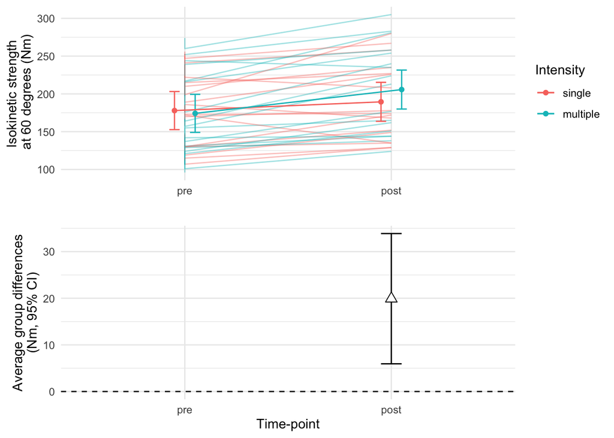

**Figure 1:** Changes in isokinetic strength at 60 degrees in knee extension for each participant and estimated averages in the three sets and one set group at time-points pre and post. Average group differences at time-point post, comparing three sets to one set.

|  | Estimate | Std. Error | t-value | Lower CI | Higher CI |
| --- | --- | --- | --- | --- | --- |
| (Intercept) | 177.9 | 12.4 | 14.37 | 153.7 | 202.2 |
| timepost | 11.6 | 5.0 | 2.30 | 1.7 | 21.5 |
| groupmultiple | -3.7 | 17.5 | -0.21 | -37.9 | 30.6 |
| timepost:groupmultiple | 19.9 | 7.1 | 2.79 | 5.9 | 33.9 |

## Discussion

As the confidence intervals contained 0, there were no difference between the groups in isokinetic strength at 60 degrees in knee extension at pre-test (95% CI: [-37.9, 30.6]). At post-test after the training intervention, there was a difference between the multiple-set and the single-set group, as the confidence interval did not contain 0 (95% CI: [5.9, 33.9]).

This study therefore suggests that three sets give a larger development of strength measured as isokinetic strength at 60 degrees in knee extension, compared to one set. Our findings indicate that three sets should be the recommended volume for strength development. That multiple-set training may be superior to single-set training, is supported by Schlumberger et al. (2001) and Galvão et al. (2004).

## Apendix R-code

```r
# Loading needed packages
library(tidyverse)
library(readxl)
library(kableExtra)
library(knitr)
library(broom)
library(lme4)
library(emmeans)
library(cowplot)

# Loading and checking the data
data <- read_csv("./data/strengthTests.csv", na = "NA")

# Preparing the data for isok.60
isok.data <- data %>%
  filter(!is.na(load)) %>% # Rempving NA from the variable "load"
  filter(exercise == "isok.60",           # Chosing isok.60
         timepoint %in% c("pre", "session1", "post")) %>%  # Choosing timepoints
  # Fixing the order of timepoint
  mutate(timepoint = factor(timepoint,
                            levels = c("pre", "session1", "post")),
     # Combining pre and session1 to one pre variable, so we just have pre and post
         time = if_else(timepoint == "post", "post", "pre"),
         time = factor(time,
                       levels = c("pre", "post")),
         # Fixing the order of groups (comparing to single)
         group = factor(group,
                        levels = c("single", "multiple")))

isok.data # Printing the results


# Plotting a figure that shows changes in strength for each participant in each group
isok.figure <- isok.data %>%
  ggplot(aes(time, load, group = subject, color = group)) + # Deciding axis and adding a color to each group
  geom_line() + # Each subject gets a line
  labs(x = "Time-point", y = "Load (Nm)") +    # Changing the axis´ names
  theme_minimal()                              # Choosing layout

isok.figure # Printing the figure
# Figure: Changes in strength for each participant in both the one and three sets groups

# Fitting a mixed model
# Want to compare the two groups and model any differences in change over time.
# A mixed model can account for repeated data by using the subject indicator as a random effect.
# Letting the groups vary from each other with time * group. Let them vary over the timepoints
# Each participant will be compared from their own starting point (intercept).
lmer1 <- lmer(load ~ time * group + (1|subject), data = isok.data)


summary(lmer1) # Printing the results

## Residual is the error we can not explain from the model (16.97 SD)

## Fixed effects from the lmer1 model
# Intercept is the average at pre in single
# Timepost is the the difference pre to post in single
# Groupmultiple is the difference between single and multiple at pre
# Timepost:groupmultiple is the difference in increase between single and multiple at post


## Variables of interest
# The difference between the groups when we have controlled for baseline after a training intervention
# 19.9 Nm difference between single and multiple at post (three sets ergo stronger)


# Residual plot to check if our assumptions are met
plot(lmer1)
# The residual variation is similar over the range of fitted values, so this is an ok model we can use.


# Model estimates
# Estimated averages at each time-point within each group
est <- emmeans(lmer1, specs = ~ time|group) # Specs specifies what means to calculate

est # Printing the results


# Plotting the model estimates (estimated averages)
# Have to convert the object created with emmeans to a data frame to be able to plot it
est.figure <- est %>%
  data.frame() %>%
  mutate(time = factor(time, levels = c("pre", "post"))) %>%
  ggplot(aes(time, emmean, group = group, color = group)) +
  geom_errorbar(aes(ymin = lower.CL, ymax = upper.CL), # Represent the 95% CI
                position = position_dodge(width = 0.2), # Moves the errorbars away from each other, same with the lines and points further down
                width = 0.1) + # Decides the width of the errorbars, the same under
  geom_line(position = position_dodge(width = 0.2)) +
  geom_point(position = position_dodge(width = 0.2)) +
  labs(x = "Time-point", y = "Isokinetic strength at 60 degrees (Nm)") + # New labels on the axis
  theme_minimal()
# Figure: Estimated averages in each group at time-points pre and post

est.figure # Printing the figure

## Tips!
# Choosing between SD og CI, CI are preferred when plotting
# Remember to only present a result once! Not the same result in both a table and a figure!


raw.est.figure <- est %>%
  # The model estimates
  data.frame() %>%
  mutate(time = factor(time,
                            levels = c("pre", "session1", "post"))) %>%
  ggplot(aes(time, emmean, group = group, color = group) ) +

  # Adding raw data
  geom_line(data = isok.data, aes(time, load, group = subject, color = group),
            alpha = 0.4) + # Add transparency to individual lines
  geom_errorbar(aes(ymin = lower.CL, ymax = upper.CL),
                position = position_dodge(width = 0.2),
                width = 0.1) +
  geom_line(position = position_dodge(width = 0.2)) +
  geom_point(position = position_dodge(width = 0.2)) +
  labs(x = "", y = "Isokinetic strength\n at 60 degrees (Nm)",
       color = "Intensity") + # New labels on the axis
  # Removing text and indicators on the x-axis as we are going to combine this plot with another, and then we use the text and indicators in that plot
  theme(axis.text.x = element_blank(),
        axis.title.x = element_blank()) +
  theme_minimal()
# Figure: Changes in strength for each participant and estimated averages in each group at time-points pre and post


raw.est.figure # Printing the figure



# Saving the confidence intervals
# Getting the 95% CI from each model coefficient
conf_intervals <- confint(lmer1)
conf_intervals
# CI at post do not contain 0. Ergo, we have proof against the null hypothesis that says that there are no difference between the groups. There is a difference!
# Present random effects as well?


# Saving the regression coefficients
# Getting the estimates of the interaction coefficients from the model
coefs <- summary(lmer1)$coef
coefs

# Using cbind (column bind) to combine the two data frames into one data frame
coef_summary <- cbind(coefs, data.frame(conf_intervals)[3:6, ])
coef_summary

# Printing a table using kable()
coef.table <- coef_summary %>%
  kable(col.names = c("Estimate", "Std. Error", "t-value", "Lower CI", "Higher CI"), # Column names
        digits = c(1, 1, 2, 1, 1),# Deciding how many decimals at each value
        caption = "**Table 1:** Coefficient estimates, standard error, t-statistic, lower and upper confidence interval at time-points pre, session1 and post in both the one and three sets group.")
# Table: Coefficient estimates, standard error, t-statistic, lower and upper confidence interval

coef.table   # Printing the table



# Plot to show "What should be the recommended volume for strength development, one or three sets?"
# Interested in the estimates "timepointsession1:groupmultiple" and "timepointpost:groupmultiple "

# Reducing the data frame and plotting it to show estimated differences between groups at  post after accounting for baseline differences
est.diff.figure <- coef_summary %>%
  mutate(coef = rownames(.)) %>%
  # Filter only the interaction variables
  filter(coef %in% c("timepost:groupmultiple")) %>%
  # Making a "timepoint" variable to represent the "isok.data" data set.
  mutate(time = gsub("time", "", coef),
         time = gsub(":groupmultiple", "", time)) %>%
  # Adding a row so that timepoint = "pre" is represented
  add_row(time = "pre", coef = "pre") %>%
  # Fixing the order of the time variable
  mutate(time = factor(time, levels = c("pre", "post"))) %>%
  # Creating the plot
  ggplot(aes(time, Estimate)) +
  # Adding a line indicating zero geom_hline (horizontal line)
  geom_hline(yintercept = 0, lty = 2) +
  # Adding errorbars and points
  geom_errorbar(aes(ymin = X2.5.., ymax = X97.5..), width = 0.1) +
  geom_point(shape = 24, size = 3, fill = "white") +
  # Changing axis titles and title in the legend
  labs(x = "Time-point", y = "Average group differences\n(Nm, 95% CI)",
       color = "Intensity") +
  theme_minimal()

est.diff.figure # Printing the figure
# Figure: Average group differences in 1 RM legpress at post, comparing 10 RM to 30 RM.

# Answer to our question: three sets should be the recommended volume
# The points show the difference between the groups at the different time-points, comparing three sets one set.


# Combining the plots to one plot
# Using "raw.est.figure" and "est.diff.figure"
figure1 <- plot_grid(raw.est.figure, est.diff.figure, ncol = 1,
          # Aligning vertically so that the x axis matches
          align = "v",
          # Setting alignment so that axis align both on the left (l) and right (r) axis
          axis = "lr")

figure1 # Printing the figure
# Figure 1: Changes in 1 RM legpress for each participant and estimated averages in each group at time-points pre and post. Average group differences in 1 RM legpress at time-point post.
```

## References

Galvão, D. A., and D. R. Taaffe. 2004. “Single- Vs. Multiple-Set Resistance Training: Recent Developments in the Controversy.” *The Journal of Strength & Conditioning Research*. https://journals.lww.com/nsca-jscr/Fulltext/2004/08000/Single__vs__Multiple_Set_Resistance_Training_.49.aspx.

Schlumberger, A., J. Stec, and D. Schmidtbleicher. 2001. “Single- Vs. Multiple-Set Strength Training in Women.” *Journal of Strength and Conditioning Research* 15 (3): 284—289. https://doi.org/10.1519/1533-4287(2001)015&lt;0284:svmsst&gt;2.0.co;2.